# HR Turnover Analysis

Orion Tran

2025-09-27

# Introduction

This project is a personal portfolio analysis that applies concepts from my Master’s in Applied Industrial-Organizational Psychology to HR data on employee turnover. It is designed as a professional-style report to both **practice evidence-based HR analytics** and to demonstrate my **ability to translate data into actionable insights** for organizations

Employee turnover is a costly challenge because replacing an employee can take months of lost productivity and additional hiring expenses. This analysis explores attrition patterns in a data set of 311 employees to answer a simple question: **what factors drive people to leave, and where should HR intervene first?**

**Recommendation:** HR should prioritize stronger onboarding, early-tenure mentoring, and targeted retention programs in Production.

# Part 1: Data Cleaning & Preparation

We begin by importing the necessary R libraries:

• **readr** for importing CSVs

• **dplyr** for data manipulation

• **tibble** for tidy tables

• **lubridate** for handling dates

• **janitor** for cleaning variable names

• **ggplot2** for visualizations

```r
library(readr)
library(dplyr)
library(janitor)
library(lubridate)
library(ggplot2)
library(tibble)
```

We then load the dataset and parse dates:

```r
# Read + clean data
turnover_data <- read_csv("~/Project Datasets/HRDataset_v14.csv") %>%
  clean_names() %>%
  mutate(
    dateof_hire         = mdy(dateof_hire),
    dateof_termination  = mdy(dateof_termination),
    last_performance_review_date = mdy(last_performance_review_date)
  )
```

Next, we set a snapshot date and engineer new features: **tenure (years at the company, continuous), salary (continuous), and engagement (continuous)**. We also drop ID variables that don’t help with analysis.

```r
# Snapshot date
snap <- max(turnover_data$dateof_termination,
            turnover_data$last_performance_review_date,
            turnover_data$dateof_hire,
            na.rm = TRUE)

# Feature engineering (continuous variables)
turnover_data <- turnover_data %>%
  mutate(
    attrition_flag = termd,
    end_date = if_else(!is.na(dateof_termination), dateof_termination, snap),
    years_at_company = as.numeric(difftime(end_date, dateof_hire, units = "days")) / 365.25,
    # Keep continuous variables instead of bands
    salary_cont = salary,
    engagement_cont = engagement_survey
  ) %>%
  select(
    -employee_name, -emp_id, -manager_id,
    -married_id, -marital_status_id, -gender_id, -emp_status_id,
    -dept_id, -perf_score_id, -position_id, -zip
  )
```

**What this shows:**

The dataset is now structured for analysis, with features ready to compare attrition rates across groups.

# Part 2: KPIs & Exploratory Data Analysis

With a clean dataset, we can now explore overall attrition and how it breaks down across key variables. We’ll start with the **overall attrition rate** as a baseline.

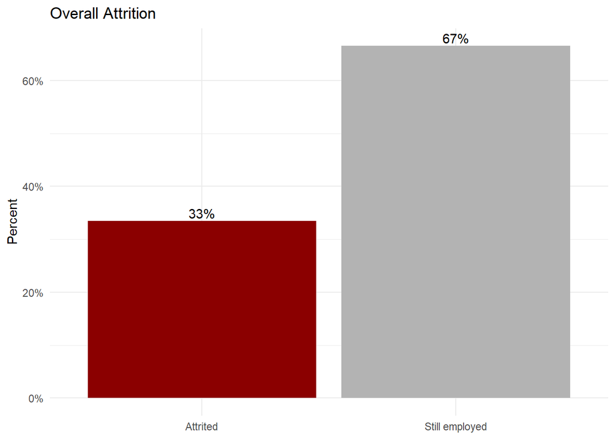

```r
# Overall attrition
overall_attrition_rate <- mean(turnover_data$attrition_flag, na.rm = TRUE)

overall_tbl <- turnover_data %>%
  mutate(attrition_status = if_else(attrition_flag == 1, "Attrited", "Still employed")) %>%
  count(attrition_status) %>%
  mutate(pct = n / sum(n))

ggplot(overall_tbl, aes(attrition_status, pct, fill = attrition_status)) +
  geom_col() +
  geom_text(aes(label = paste0(round(pct*100), "%")), vjust = -0.3) +
  scale_y_continuous(labels = scales::percent) +
  scale_fill_manual(values = c("Attrited" = "darkred", "Still employed" = "gray70")) +
  labs(title = "Overall Attrition", x = NULL, y = "Percent") +
  theme_minimal() +
  guides(fill = "none")
```

**What this shows:**

Overall attrition is 33%. That means nearly 1 out of 3 employees leave, setting the stage for deeper analysis.

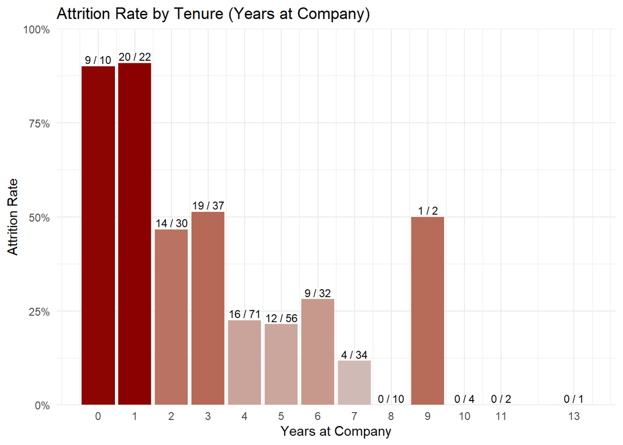

```r
# Attrition by tenure
tenure_attrition <- turnover_data %>%
  mutate(tenure_year = floor(years_at_company)) %>%
  group_by(tenure_year) %>%
  summarise(
    headcount = n(),
    n_attrited = sum(attrition_flag == 1, na.rm = TRUE),
    attrition_rate = n_attrited / headcount,
    .groups = "drop"
  )

ggplot(tenure_attrition, aes(x = tenure_year, y = attrition_rate, fill = attrition_rate)) +
  geom_col() +
  geom_text(aes(label = paste0(n_attrited, " / ", headcount)), vjust = -0.3, size = 3) +
  scale_y_continuous(labels = scales::percent, expand = expansion(mult = c(0, 0.1))) +
  scale_x_continuous(breaks = tenure_attrition$tenure_year) +
  scale_fill_gradient(low = "lightgray", high = "darkred") +
  labs(title = "Attrition Rate by Tenure (Years at Company)",
       x = "Years at Company", y = "Attrition Rate") +
  guides(fill = "none") +
  theme_minimal()
```

**What this shows:**

Attrition is **heavily front-loaded**

**Takeaway: tenure — especially the first year — is a critical risk period.**

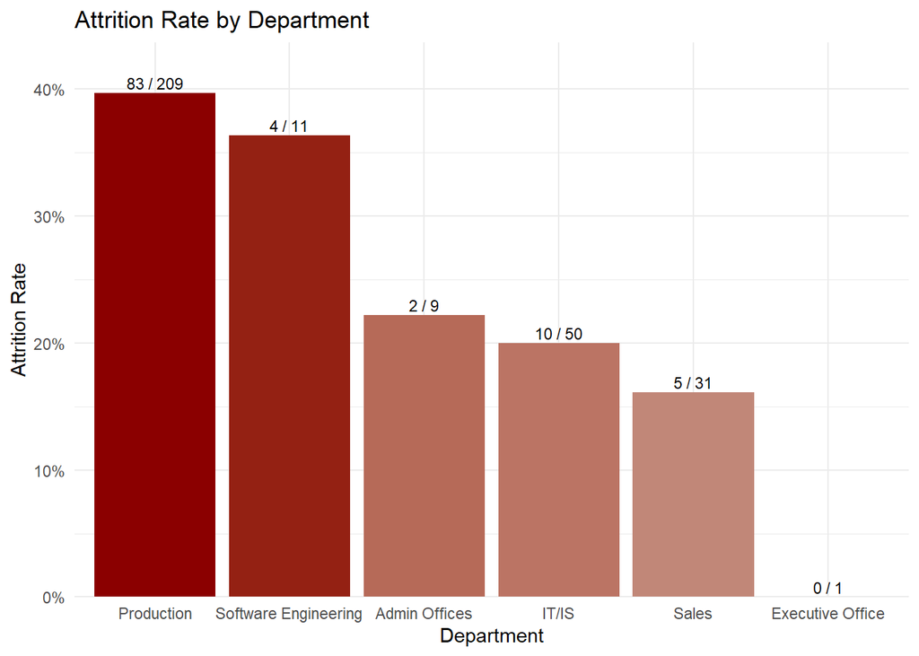

```r
# Attrition by department
dept_attrition <- turnover_data %>%
  group_by(department) %>%
  summarise(
    headcount = n(),
    n_attrited = sum(attrition_flag == 1, na.rm = TRUE),
    attrition_rate = n_attrited / headcount,
    .groups = "drop"
  )

ggplot(dept_attrition, aes(x = reorder(department, -attrition_rate), y = attrition_rate, fill = attrition_rate)) +
  geom_col() +
  geom_text(aes(label = paste0(n_attrited, " / ", headcount)), vjust = -0.3, size = 3) +
  scale_y_continuous(labels = scales::percent, expand = expansion(mult = c(0, 0.1))) +
  scale_fill_gradient(low = "lightgray", high = "darkred") +
  labs(title = "Attrition Rate by Department",
       x = "Department", y = "Attrition Rate") +
  guides(fill = "none") +
  theme_minimal()
```

**What this shows:**

The **Production department** has the **highest attrition rate**. While Software Engineering also appears high, its small headcount makes the comparison less reliable.

This identifies Production as the priority area for deeper analysis.

# Part 2b: Drill-Down within Production

Since Production has the highest attrition, we drill down further. We’ll first look at tenure within Production, then test satisfaction and engagement levels.

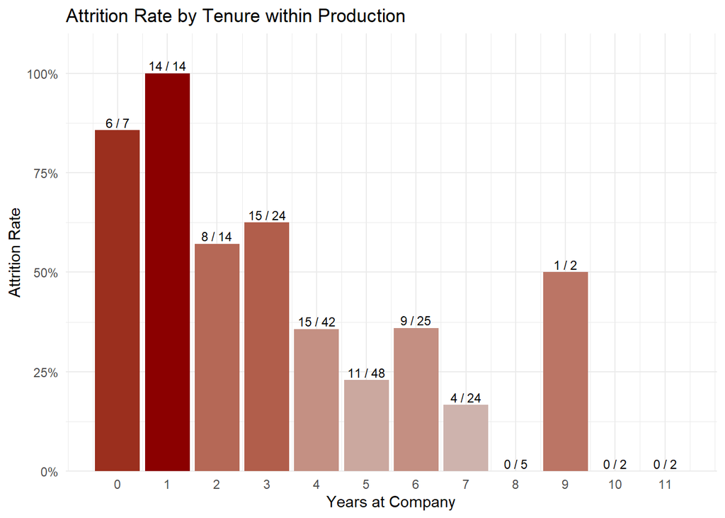

```r
# Attrition by tenure in Production
prod_tenure_attrition <- turnover_data %>%
  filter(department == "Production") %>%
  mutate(tenure_year = floor(years_at_company)) %>%
  group_by(tenure_year) %>%
  summarise(
    headcount = n(),
    n_attrited = sum(attrition_flag == 1, na.rm = TRUE),
    attrition_rate = n_attrited / headcount,
    .groups = "drop"
  )

ggplot(prod_tenure_attrition, aes(x = tenure_year, y = attrition_rate, fill = attrition_rate)) +
  geom_col() +
  geom_text(aes(label = paste0(n_attrited, " / ", headcount)),
            vjust = -0.3, size = 3) +
  scale_y_continuous(labels = scales::percent, expand = expansion(mult = c(0, 0.1))) +
  scale_x_continuous(breaks = prod_tenure_attrition$tenure_year) +
  scale_fill_gradient(low = "lightgray", high = "darkred") +
  labs(title = "Attrition Rate by Tenure within Production",
       x = "Years at Company", y = "Attrition Rate") +
  guides(fill = "none") +
  theme_minimal()
```

**What this shows:**

The spike is clear: **first-year Production employees leave at much higher rates**, than longer-tenure employees (being at 100%). This confirms the **onboarding period is the main vulnerability.**

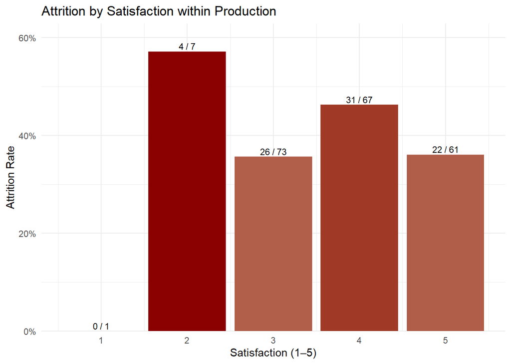

```r
# Attrition by satisfaction in Production
prod_satisfaction_attrition <- turnover_data %>%
  filter(department == "Production") %>%
  group_by(emp_satisfaction) %>%
  summarise(
    headcount = n(),
    n_attrited = sum(attrition_flag == 1, na.rm = TRUE),
    attrition_rate = n_attrited / headcount,
    .groups = "drop"
  )

ggplot(prod_satisfaction_attrition, aes(x = emp_satisfaction, y = attrition_rate, fill = attrition_rate)) +
  geom_col() +
  geom_text(aes(label = paste0(n_attrited, " / ", headcount)), vjust = -0.3, size = 3) +
  scale_y_continuous(labels = scales::percent, expand = expansion(mult = c(0, 0.1))) +
  scale_x_continuous(breaks = prod_satisfaction_attrition$emp_satisfaction) +
  scale_fill_gradient(low = "lightgray", high = "darkred") +
  labs(title = "Attrition by Satisfaction within Production",
       x = "Satisfaction (1–5)", y = "Attrition Rate") +
  guides(fill = "none") +
  theme_minimal()
```

**What this shows:**

Attrition varies somewhat by satisfaction, but the signal is inconsistent. Satisfaction matters less than tenure.

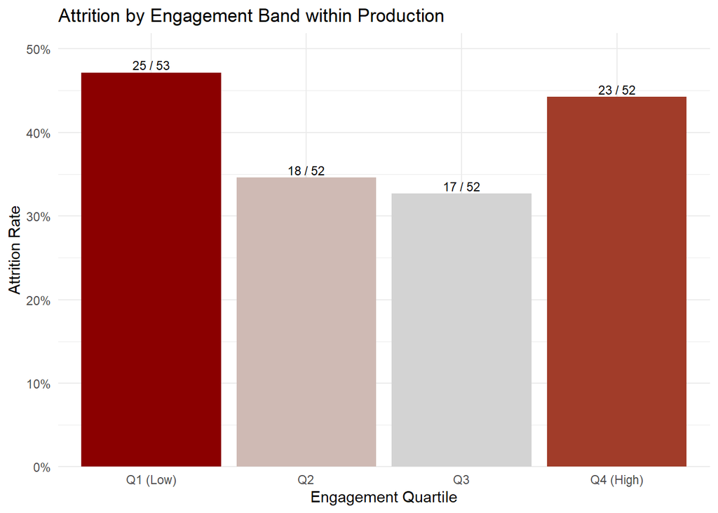

```r
# Attrition by engagement bands in Production
prod_engagement_attrition <- turnover_data %>%
  filter(department == "Production") %>%
  mutate(engagement_band = ntile(engagement_survey, 4)) %>%
  group_by(engagement_band) %>%
  summarise(
    headcount = n(),
    n_attrited = sum(attrition_flag == 1, na.rm = TRUE),
    attrition_rate = n_attrited / headcount,
    .groups = "drop"
  ) %>%
  mutate(engagement_band = factor(engagement_band,
                                  labels = c("Q1 (Low)", "Q2", "Q3", "Q4 (High)")))

ggplot(prod_engagement_attrition, aes(x = engagement_band, y = attrition_rate, fill = attrition_rate)) +
  geom_col() +
  geom_text(aes(label = paste0(n_attrited, " / ", headcount)), vjust = -0.3, size = 3) +
  scale_y_continuous(labels = scales::percent, expand = expansion(mult = c(0, 0.1))) +
  scale_fill_gradient(low = "lightgray", high = "darkred") +
  labs(title = "Attrition by Engagement Band within Production",
       x = "Engagement Quartile", y = "Attrition Rate") +
  guides(fill = "none") +
  theme_minimal()
```

**What this shows:**

Attrition is higher in the lowest engagement quartile, but the effect is modest. Like satisfaction, engagement is secondary to tenure.

# Part 3: Logistic Regression

To confirm which factors matter when controlling for others, we ran a logistic regression with **continuous predictors (tenure in years, salary, engagement score, and satisfaction), plus department indicators**.

```r
# Logistic regression with continuous predictors
model <- glm(
  attrition_flag ~ department + years_at_company + emp_satisfaction +
    engagement_cont + salary_cont,
  data = turnover_data,
  family = binomial()
)

# Odds ratios
or <- exp(coef(model))
ci <- confint.default(model)
ci <- exp(ci)
p  <- summary(model)$coefficients[, "Pr(>|z|)"]

or_table <- tibble(
  term = names(or),
  odds_ratio = round(as.numeric(or), 2),
  conf_low   = round(as.numeric(ci[, 1]), 2),
  conf_high  = round(as.numeric(ci[, 2]), 2),
  p_value    = round(as.numeric(p), 3)
) %>%
  arrange(p_value)

or_table
```

```
## # A tibble: 10 × 5
##    term                           odds_ratio conf_low conf_high p_value
##    <chr>                               <dbl>    <dbl>     <dbl>   <dbl>
##  1 years_at_company                     0.48     0.4       0.59   0
##  2 departmentProduction                 5.96     0.85     41.6    0.072
##  3 departmentSoftware Engineering       5.74     0.5      65.6    0.16
##  4 (Intercept)                          2.87     0.15     55.7    0.485
##  5 departmentIT/IS                      0.66     0.08      5.49   0.701
##  6 departmentSales                      1.52     0.17     13.5    0.709
##  7 emp_satisfaction                     1.04     0.75      1.43   0.827
##  8 salary_cont                          1        1         1      0.933
##  9 departmentExecutive Office           0        0       Inf      0.99
## 10 engagement_cont                      1        0.69      1.44   0.992
```

**What this shows:**

• **Tenure** has the strongest independent effect: each additional year at the company substantially **reduces the odds of leaving**.

• **Production** still shows elevated attrition risk, though the difference is less statistically certain.

• **Salary, satisfaction, and engagement** show little added effect once tenure is accounted for.

**Takeaway: tenure is the dominant predictor of attrition.**

# Part 4: Focused Statistical Tests

We now use targeted tests to validate patterns observed earlier.

```r
# Department × Attrition
tbl_dept <- table(turnover_data$department, turnover_data$attrition_flag)
chi_res <- chisq.test(tbl_dept)
# Tenure vs Attrition
t_res <- t.test(years_at_company ~ attrition_flag, data = turnover_data)

# Production vs Others
turnover_data <- turnover_data %>%
  mutate(prod_vs_other = if_else(department == "Production", "Production", "Other"))
tbl_prod <- table(turnover_data$prod_vs_other, turnover_data$attrition_flag)
prod_chi <- chisq.test(tbl_prod)

# Summary
test_summary <- tribble(
  ~Test, ~Variables, ~Statistic, ~p_value, ~Interpretation,

  "Chi-Square", "Department × Attrition", round(chi_res$statistic, 2), signif(chi_res$p.value, 3),
  ifelse(chi_res$p.value < 0.05, "Attrition differs by department", "No difference across departments"),

  "t-Test", "Tenure (years) × Attrition", round(t_res$statistic, 2), signif(t_res$p.value, 3),
  ifelse(t_res$p.value < 0.05, "Average tenure differs (shorter = higher attrition)", "No significant tenure difference"),

  "Chi-Square", "Production vs Others × Attrition", round(prod_chi$statistic, 2), signif(prod_chi$p.value, 3),
  ifelse(prod_chi$p.value < 0.05, "Attrition significantly higher in Production", "No significant Production difference")
)

test_summary
```

```
## # A tibble: 3 × 5
##   Test       Variables                        Statistic  p_value Interpretation
##   <chr>      <chr>                                <dbl>    <dbl> <chr>
## 1 Chi-Square Department × Attrition               13.0  2.36e- 2 Attrition diff…
## 2 t-Test     Tenure (years) × Attrition            8.55 3.19e-15 Average tenure…
## 3 Chi-Square Production vs Others × Attrition     10.4  1.25e- 3 Attrition sign…
```

**What this shows:**

•Attrition **differs by department** (Production is worst).

•Employees who leave have **significantly shorter tenure**.

•Production has **significantly higher attrition** than all other groups combined.

### Return on Investment (ROI)

```r
# ROI estimate (aggressive: all employees, 9 months salary)
avg_salary <- mean(turnover_data$salary, na.rm = TRUE)
aggressive_savings <- avg_salary * 0.75 * (nrow(turnover_data) * 0.05)

# Conservative version:
# - Use 6 months of salary (0.5 instead of 0.75)
# - Apply 5% reduction only to Production employees
prod_count <- nrow(filter(turnover_data, department == "Production"))
conservative_savings <- avg_salary * 0.5 * (prod_count * 0.05)

aggressive_savings
```

```
## [1] 804953.7
```

```r
conservative_savings
```

```
## [1] 360633.1
```

Attrition is **not evenly distributed** across the company. The highest-risk group is **Production employees in their first year of tenure**, where turnover is heavily concentrated. Logistic regression confirmed that **tenure is the dominant predictor** of attrition, while satisfaction, engagement, and salary play a smaller role once tenure is considered.

Once attrition in Production is stabilized, applying similar approaches across departments could unlock even greater savings — potentially exceeding **$800,000 each year**.

# Recommendations

To capture these savings and stabilize the workforce, HR should prioritize:

• **Stronger onboarding**  
• **Early-tenure mentoring and support**  
• **Targeted retention programs in Production**

These actions directly address the most vulnerable employees, improve retention, and create a tangible return on investment.

# References

Society for Human Resource Management. (2016). Human capital benchmarking report. SHRM. https://bestmanagementarticles.com/wp-content/uploads/SHRM-2016-Human-Capital-Benchmarking-Report.pdf